# Analýza počtu krokov podľa dňa v týždni

Samuel

2026-04-07

# 1. Definícia základných pojmov

- **Štatistický znak Y:** počet krokov za deň *(kroky)* (kvantitatívny znak)
- **Faktor A:** deň v týždni (kvalitatívny znak)
- **Štatistická jednotka:** jeden deň
- **Základný súbor:** všetky dni zaznamenané v aplikácii iPhone Zdravie
- **Výberový súbor:** všetky dostupné dni z exportu dát

# 2. Načítanie a príprava dát

```r
library(XML)
library(lubridate)

# Načítanie XML exportu z iPhone (uprav cestu k súboru, ak je iná)
xml_data <- xmlParse("export.xml")
records  <- getNodeSet(xml_data, "//Record")

# Prevedenie na data frame
df_raw <- do.call(rbind, lapply(records, function(r) {
  data.frame(
    type      = xmlGetAttr(r, "type"),
    value     = xmlGetAttr(r, "value"),
    startDate = xmlGetAttr(r, "startDate"),
    stringsAsFactors = FALSE
  )
}))

# Filtrovanie krokov a konverzia typov
df_steps <- df_raw[df_raw$type == "HKQuantityTypeIdentifierStepCount", ]
df_steps$value     <- as.numeric(df_steps$value)
df_steps$startDate <- as.POSIXct(df_steps$startDate, format = "%Y-%m-%d %H:%M:%S %z")
df_steps$datum     <- as.Date(df_steps$startDate)

# Súčet krokov za každý deň
df_daily <- aggregate(value ~ datum, data = df_steps, FUN = sum)
colnames(df_daily) <- c("datum", "kroky")

# Pridanie dňa v týždni ako faktora
df_daily$den <- factor(
  wday(df_daily$datum, week_start = 1),
  levels = 1:7,
  labels = c("Pon", "Uto", "Str", "Stv", "Pia", "Sob", "Ned")
)

data_vstup <- df_daily
```

# 3. Základné číselné charakteristiky

```r
summary(data_vstup$kroky)
```

```
##    Min. 1st Qu.  Median    Mean 3rd Qu.    Max.
##      55    3730    6077    7007    9517   27142
```

```r
sd(data_vstup$kroky)
```

```
## [1] 4645.387
```

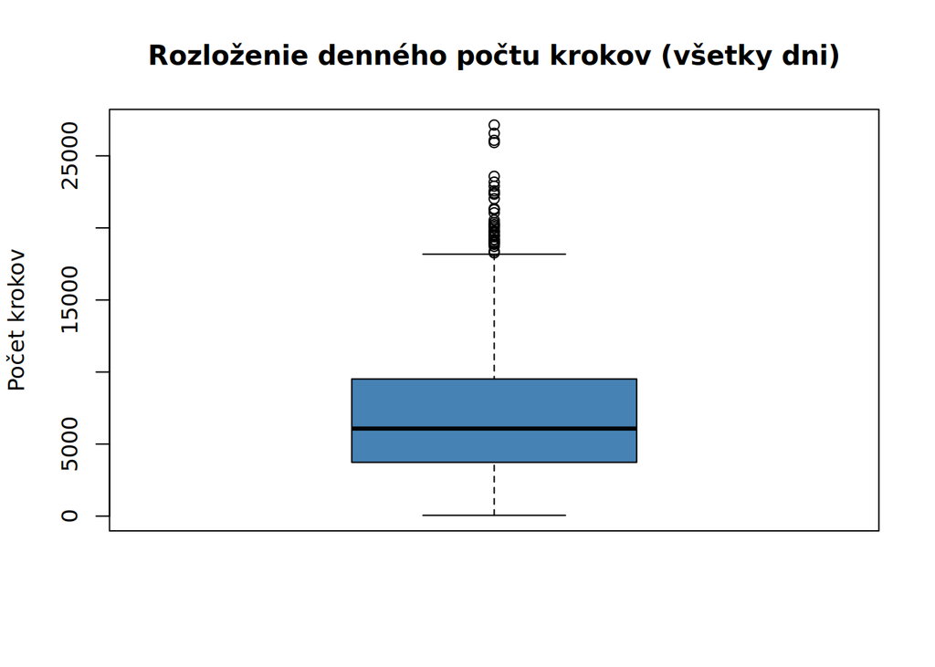

```r
boxplot(data_vstup$kroky,
        main = "Rozloženie denného počtu krokov (všetky dni)",
        ylab = "Počet krokov",
        col  = "steelblue")
```

# 4. Test normality (Shapiro-Wilkov test)

Na určenie správneho testu na porovnanie dní musíme overiť, či majú dáta normálne rozdelenie.  
**H0:** Sledovaný znak Y má normálové rozdelenie.  
**H1:** Sledovaný znak Y nemá normálové rozdelenie.  
*(Hladina významnosti alfa = 0,05)*

```r
shapiro.test(data_vstup$kroky[data_vstup$den == "Pon"])
```

```
##
##  Shapiro-Wilk normality test
##
## data:  data_vstup$kroky[data_vstup$den == "Pon"]
## W = 0.93486, p-value = 4.072e-07
```

```r
shapiro.test(data_vstup$kroky[data_vstup$den == "Uto"])
```

```
##
##  Shapiro-Wilk normality test
##
## data:  data_vstup$kroky[data_vstup$den == "Uto"]
## W = 0.93559, p-value = 4.645e-07
```

```r
shapiro.test(data_vstup$kroky[data_vstup$den == "Str"])
```

```
##
##  Shapiro-Wilk normality test
##
## data:  data_vstup$kroky[data_vstup$den == "Str"]
## W = 0.94523, p-value = 3.048e-06
```

```r
shapiro.test(data_vstup$kroky[data_vstup$den == "Stv"])
```

```
##
##  Shapiro-Wilk normality test
##
## data:  data_vstup$kroky[data_vstup$den == "Stv"]
## W = 0.94338, p-value = 2.124e-06
```

```r
shapiro.test(data_vstup$kroky[data_vstup$den == "Pia"])
```

```
##
##  Shapiro-Wilk normality test
##
## data:  data_vstup$kroky[data_vstup$den == "Pia"]
## W = 0.95932, p-value = 5.76e-05
```

```r
shapiro.test(data_vstup$kroky[data_vstup$den == "Sob"])
```

```
##
##  Shapiro-Wilk normality test
##
## data:  data_vstup$kroky[data_vstup$den == "Sob"]
## W = 0.89826, p-value = 1.446e-09
```

```r
shapiro.test(data_vstup$kroky[data_vstup$den == "Ned"])
```

```
##
##  Shapiro-Wilk normality test
##
## data:  data_vstup$kroky[data_vstup$den == "Ned"]
## W = 0.80042, p-value = 3.801e-14
```

# 5. Porovnanie počtu krokov podľa dňa v týždni (ANOVA)

### Bartlettov test (Rovnosť rozptylov)

**H0:** Rozptyly vo všetkých dňoch sú rovnaké.  
**H1:** Aspoň jeden rozptyl sa líši.

```r
bartlett.test(kroky ~ den, data_vstup)
```

```
##
##  Bartlett test of homogeneity of variances
##
## data:  kroky by den
## Bartlett's K-squared = 6.1317, df = 6, p-value = 0.4086
```

### Analýza rozptylu (ANOVA)

**H0:** Priemerný počet krokov je vo všetkých dňoch rovnaký.  
**H1:** Aspoň v jednom dni je priemerný počet krokov iný.

```r
vysledok_anova <- aov(kroky ~ den, data_vstup)
summary(vysledok_anova)
```

```
##               Df    Sum Sq   Mean Sq F value   Pr(>F)
## den            6 1.021e+09 170193668   8.165 1.13e-08 ***
## Residuals   1214 2.531e+10  20845118
## ---
## Signif. codes:  0 '***' 0.001 '**' 0.01 '*' 0.05 '.' 0.1 ' ' 1
```

### Tukeyova metóda mnohonásobného porovnávania

```r
TukeyHSD(vysledok_anova)
```

```
##   Tukey multiple comparisons of means
##     95% family-wise confidence level
##
## Fit: aov(formula = kroky ~ den, data = data_vstup)
##
## $den
##               diff        lwr          upr     p adj
## Uto-Pon   158.5086 -1282.9545  1599.971644 0.9999060
## Str-Pon   473.6511  -969.8816  1917.183755 0.9605306
## Stv-Pon   792.2028  -651.3298  2235.735479 0.6689100
## Pia-Pon  1098.4114  -343.0516  2539.874501 0.2694588
## Sob-Pon  -645.8604 -2089.3930   797.672260 0.8420335
## Ned-Pon -1833.3949 -3276.9275  -389.862222 0.0034827
## Str-Uto   315.1425 -1128.3901  1758.675183 0.9952730
## Stv-Uto   633.6943  -809.8384  2077.226907 0.8537235
## Pia-Uto   939.9029  -501.5602  2381.365930 0.4635436
## Sob-Uto  -804.3690 -2247.9016   639.163689 0.6525296
## Ned-Uto -1991.9034 -3435.4361  -548.370794 0.0009614
## Stv-Str   318.5517 -1127.0475  1764.150998 0.9950253
## Pia-Str   624.7603  -818.7723  2068.292983 0.8619937
## Sob-Str -1119.5115 -2565.1108   326.087779 0.2510006
## Ned-Str -2307.0460 -3752.6453  -861.446704 0.0000557
## Pia-Stv   306.2086 -1137.3241  1749.741259 0.9959636
## Sob-Stv -1438.0632 -2883.6625     7.536055 0.0522447
## Ned-Stv -2625.5977 -4071.1970 -1179.998428 0.0000020
## Sob-Pia -1744.2718 -3187.8045  -300.739168 0.0068315
## Ned-Pia -2931.8063 -4375.3390 -1488.273651 0.0000001
## Ned-Sob -1187.5345 -2633.1338   258.064791 0.1884922
```

# 6. Vizualizácia rozdielov medzi dňami

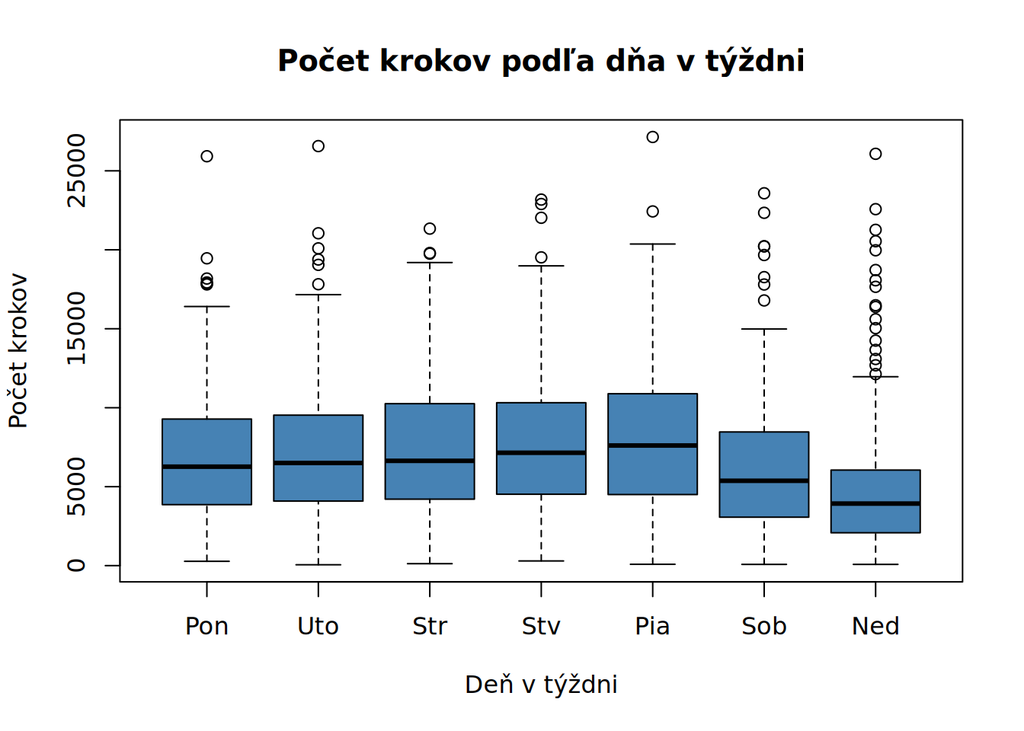

```r
boxplot(kroky ~ den, data_vstup,
        main = "Počet krokov podľa dňa v týždni",
        xlab = "Deň v týždni",
        ylab = "Počet krokov",
        col  = "steelblue")
```

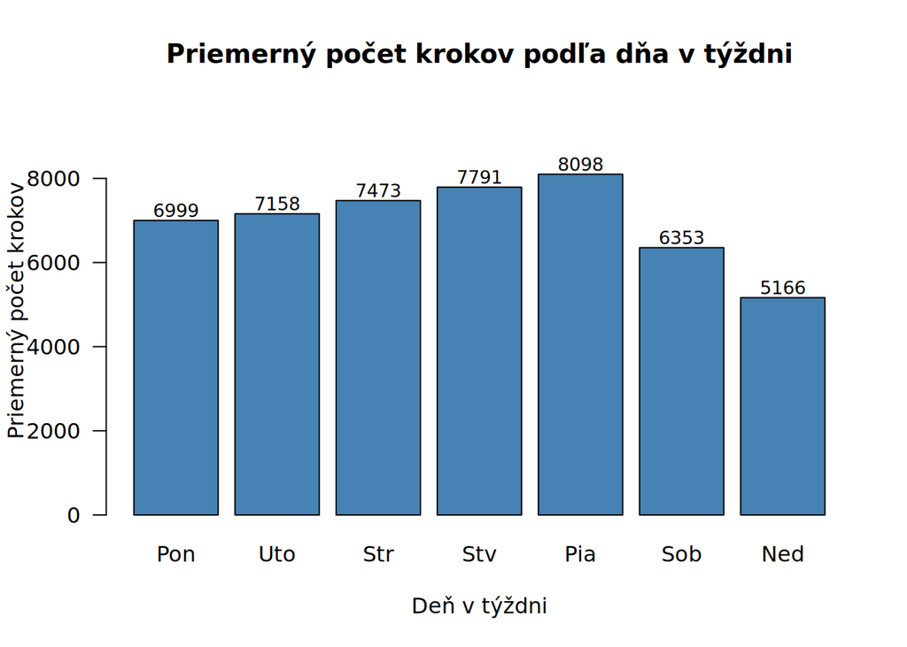

```r
priemery <- tapply(data_vstup$kroky, data_vstup$den, mean)

bp <- barplot(
  priemery,
  main  = "Priemerný počet krokov podľa dňa v týždni",
  xlab  = "Deň v týždni",
  ylab  = "Priemerný počet krokov",
  col   = "steelblue",
  ylim  = c(0, max(priemery) * 1.2),
  las   = 1
)

text(bp, priemery + max(priemery) * 0.03,
     labels = round(priemery, 0), cex = 0.85)
```

# 7. Záver

Z analýzy denného počtu krokov zaznamenaných aplikáciou iPhone Zdravie vyplývajú nasledujúce zistenia:

- **Základná štatistika:** Celkový priemerný denný počet krokov za sledované obdobie je **7 007 krokov**, pričom medián je **6 077 krokov**.
- **Výkyvy v aktivite:** Najaktívnejším dňom podľa priemeru sa javí **piatok**, zatiaľ čo najnižšiu pohybovú aktivitu zaznamenávame v **nedeľu**.

Existuje štatisticky významný rozdiel v priemernom počte krokov medzi jednotlivými dňami v týždni. Tukeyov test mnohonásobného porovnávania odhaľuje, že štatisticky významné rozdiely existujú najmä medzi nedeľou a ostatnými dňami (pondelok, utorok, streda, štvrtok, piatok). Nedeľa vykazuje výrazne nižší priemerný počet krokov v porovnaní s pracovnými dňami. Rozdiel medzi nedeľou a sobotou nie je štatisticky významný. Celkovo možno povedať, že pohybová aktivita je v nedeľu výrazne nižšia ako počas pracovného týždňa.